# Netflix and Amazon Movies and TV Shows

## 7. Merging Netflix and Amazon Prime

```python
# Merge the datasets based on common columns (e.g., show_id) with custom suffixes
merged_df = pd.merge(netflix_df, amazon_df, on="show_id", how="inner", suffixes=("_netflix", "_amazon"))

# Set 'show_id' as index
merged_df = merged_df.set_index(['show_id'])
```

```python
merged_df.head(2)
```

| show_id | type_netflix | title_netflix | director_netflix | cast_netflix | country_netflix | date_added_netflix | release_year_netflix | rating_netflix | duration_netflix | listed_in_netflix | ... | title_amazon | director_amazon | cast_amazon | country_amazon | date_added_amazon | release_year_amazon | rating_amazon | duration_amazon | listed_in_amazon | Media Type_amazon |
| --- | --- | --- | --- | --- | --- | --- | --- | --- | --- | --- | --- | --- | --- | --- | --- | --- | --- | --- | --- | --- | --- |
| s8 | Movie | Sankofa | Haile Gerima | Kofi Ghanaba, Oyafunmike Ogunlano, Alexandra D... | United States, Ghana, Burkina Faso, United Kin... | 2021-09-24 | 1993 | TV-MA | 125 min | Dramas, Independent Movies, International Movies | ... | Grease Live! | Thomas Kail, Alex Rudzinski | Julianne Hough, Aaron Tveit, Vanessa Hudgens, ... | United States | 2021-03-30 | 2016 | NaN | 131 min | Comedy | Movie |
| s9 | TV Show | The Great British Baking Show | Andy Devonshire | Mel Giedroyc, Sue Perkins, Mary Berry, Paul Ho... | United Kingdom | 2021-09-24 | 2021 | TV-14 | 9 Seasons | British TV Shows, Reality TV | ... | Global Meltdown | Daniel Gilboy | Michael Paré, Leanne Khol Young, Patrick J. Ma... | Canada | 2021-03-30 | 2017 | NaN | 87 min | Action, Science Fiction, Suspense | Movie |

2 rows × 22 columns

```python
merged_df.dtypes
```

```
type_netflix                    object
title_netflix                   object
director_netflix                object
cast_netflix                    object
country_netflix                 object
date_added_netflix      datetime64[ns]
release_year_netflix             int64
rating_netflix                  object
duration_netflix                object
listed_in_netflix               object
Media Type_netflix              object
type_amazon                     object
title_amazon                    object
director_amazon                 object
cast_amazon                     object
country_amazon                  object
date_added_amazon       datetime64[ns]
release_year_amazon              int64
rating_amazon                   object
duration_amazon                 object
listed_in_amazon                object
Media Type_amazon               object
dtype: object
```

### 7.1 Create a new csv file from the merge

- The index=False parameter is used to exclude the row index from being saved as a separate column in the CSV file.

```python
# Save the merged DataFrame to a CSV file
merged_df.to_csv("merged_dataset.csv", index=False)
```

```python
# Load the merged dataset
merged_df = pd.read_csv("merged_dataset.csv")

merged_df.head(2)
```

|  | type_netflix | title_netflix | director_netflix | cast_netflix | country_netflix | date_added_netflix | release_year_netflix | rating_netflix | duration_netflix | listed_in_netflix | ... | title_amazon | director_amazon | cast_amazon | country_amazon | date_added_amazon | release_year_amazon | rating_amazon | duration_amazon | listed_in_amazon | Media Type_amazon |
| --- | --- | --- | --- | --- | --- | --- | --- | --- | --- | --- | --- | --- | --- | --- | --- | --- | --- | --- | --- | --- | --- |
| 0 | Movie | Sankofa | Haile Gerima | Kofi Ghanaba, Oyafunmike Ogunlano, Alexandra D... | United States, Ghana, Burkina Faso, United Kin... | 2021-09-24 | 1993 | TV-MA | 125 min | Dramas, Independent Movies, International Movies | ... | Grease Live! | Thomas Kail, Alex Rudzinski | Julianne Hough, Aaron Tveit, Vanessa Hudgens, ... | United States | 2021-03-30 | 2016 | NaN | 131 min | Comedy | Movie |
| 1 | TV Show | The Great British Baking Show | Andy Devonshire | Mel Giedroyc, Sue Perkins, Mary Berry, Paul Ho... | United Kingdom | 2021-09-24 | 2021 | TV-14 | 9 Seasons | British TV Shows, Reality TV | ... | Global Meltdown | Daniel Gilboy | Michael Paré, Leanne Khol Young, Patrick J. Ma... | Canada | 2021-03-30 | 2017 | NaN | 87 min | Action, Science Fiction, Suspense | Movie |

2 rows × 22 columns

```python
merged_df.shape
```

```
(5332, 22)
```

```python
merged_df.describe(include='all')
```

|  | type_netflix | title_netflix | director_netflix | cast_netflix | country_netflix | date_added_netflix | release_year_netflix | rating_netflix | duration_netflix | listed_in_netflix | ... | title_amazon | director_amazon | cast_amazon | country_amazon | date_added_amazon | release_year_amazon | rating_amazon | duration_amazon | listed_in_amazon | Media Type_amazon |
| --- | --- | --- | --- | --- | --- | --- | --- | --- | --- | --- | --- | --- | --- | --- | --- | --- | --- | --- | --- | --- | --- |
| count | 5332 | 5332 | 5332 | 5332 | 5332 | 5332 | 5332.000000 | 5332 | 5332 | 5332 | ... | 5332 | 5332 | 4659 | 361 | 71 | 5332.000000 | 5152 | 5332 | 5332 | 5332 |
| unique | 2 | 5332 | 3945 | 5200 | 604 | 1450 | NaN | 14 | 198 | 335 | ... | 5332 | 3419 | 4450 | 54 | 50 | NaN | 21 | 209 | 422 | 2 |
| top | Movie | Sankofa | Raúl Campos, Jan Suter | Samuel West | United States | 2020-01-01 | NaN | TV-MA | 94 min | Dramas, International Movies | ... | Grease Live! | Unknown | Maggie Binkley | United States | 2021-08-27 | NaN | 13+ | 1 Season | Drama | Movie |
| freq | 5185 | 1 | 18 | 10 | 1846 | 92 | NaN | 1822 | 135 | 336 | ... | 1 | 1135 | 30 | 134 | 4 | NaN | 1153 | 746 | 561 | 4317 |
| mean | NaN | NaN | NaN | NaN | NaN | NaN | 2012.742123 | NaN | NaN | NaN | ... | NaN | NaN | NaN | NaN | NaN | 2008.703113 | NaN | NaN | NaN | NaN |
| std | NaN | NaN | NaN | NaN | NaN | NaN | 9.625831 | NaN | NaN | NaN | ... | NaN | NaN | NaN | NaN | NaN | 18.727553 | NaN | NaN | NaN | NaN |
| min | NaN | NaN | NaN | NaN | NaN | NaN | 1942.000000 | NaN | NaN | NaN | ... | NaN | NaN | NaN | NaN | NaN | 1920.000000 | NaN | NaN | NaN | NaN |
| 25% | NaN | NaN | NaN | NaN | NaN | NaN | 2011.000000 | NaN | NaN | NaN | ... | NaN | NaN | NaN | NaN | NaN | 2007.000000 | NaN | NaN | NaN | NaN |
| 50% | NaN | NaN | NaN | NaN | NaN | NaN | 2016.000000 | NaN | NaN | NaN | ... | NaN | NaN | NaN | NaN | NaN | 2016.000000 | NaN | NaN | NaN | NaN |
| 75% | NaN | NaN | NaN | NaN | NaN | NaN | 2018.000000 | NaN | NaN | NaN | ... | NaN | NaN | NaN | NaN | NaN | 2020.000000 | NaN | NaN | NaN | NaN |
| max | NaN | NaN | NaN | NaN | NaN | NaN | 2021.000000 | NaN | NaN | NaN | ... | NaN | NaN | NaN | NaN | NaN | 2021.000000 | NaN | NaN | NaN | NaN |

11 rows × 22 columns

```python
merged_df.columns
```

```
Index(['type_netflix', 'title_netflix', 'director_netflix', 'cast_netflix',
       'country_netflix', 'date_added_netflix', 'release_year_netflix',
       'rating_netflix', 'duration_netflix', 'listed_in_netflix',
       'Media Type_netflix', 'type_amazon', 'title_amazon', 'director_amazon',
       'cast_amazon', 'country_amazon', 'date_added_amazon',
       'release_year_amazon', 'rating_amazon', 'duration_amazon',
       'listed_in_amazon', 'Media Type_amazon'],
      dtype='object')
```

### 7.2 Number of Movies and TV Shows in each Platform

- Comparing the availability of movies and TV shows between Netflix and Amazon Prime.
- The count of movies and TV shows for each platform is then calculated.
- The bar chart is plotted to compare the counts of movies and TV shows between Netflix and Amazon Prime.
- Compare the availability of movies and TV shows between Netflix and Amazon Prime based on the merged dataset.

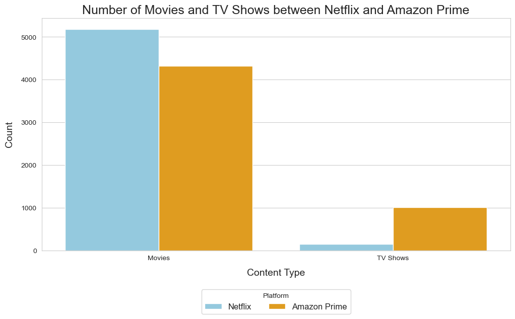

```python
# Count movies and TV shows for Netflix
netflix_movies_count = len(merged_df[merged_df["type_netflix"] == "Movie"])
netflix_tvshows_count = len(merged_df[merged_df["type_netflix"] == "TV Show"])

# Count movies and TV shows for Amazon Prime
prime_movies_count = len(merged_df[merged_df["type_amazon"] == "Movie"])
prime_tvshows_count = len(merged_df[merged_df["type_amazon"] == "TV Show"])

# Create grouped bar chart
labels = ["Movies", "TV Shows"]
netflix_counts = [netflix_movies_count, netflix_tvshows_count]
prime_counts = [prime_movies_count, prime_tvshows_count]

# Create a DataFrame for the data
data = {
    "Platform": ["Netflix"] * 2 + ["Amazon Prime"] * 2,
    "Media Type": labels * 2,
    "Count": netflix_counts + prime_counts
}
df = pd.DataFrame(data)

# Set a custom color palette
my_palette = ["skyblue", "orange"]

# Set Seaborn style and remove the black bar
sns.set_style("whitegrid")
sns.set_palette(my_palette)
sns.despine(left=True, bottom=True)

# Plot the grouped bar chart
plt.figure(figsize=(12, 6))
ax = sns.barplot(data=df, x="Media Type", y="Count", hue="Platform")
plt.xlabel("Content Type", fontsize=14, labelpad=10)
plt.ylabel("Count", fontsize=14, labelpad=10)
plt.title("Number of Movies and TV Shows between Netflix and Amazon Prime", fontsize=18)

# Move the legend to the center
plt.legend(title="Platform", bbox_to_anchor=(0.5, -0.15), loc='upper center', ncol=2, fontsize=12)

plt.show()
```

### 7.3 Putting the df into an excel file

```python
# Count movies and TV shows for Netflix
netflix_movies_count = len(merged_df[merged_df["type_netflix"] == "Movie"])
netflix_tvshows_count = len(merged_df[merged_df["type_netflix"] == "TV Show"])

# Count movies and TV shows for Amazon Prime
prime_movies_count = len(merged_df[merged_df["type_amazon"] == "Movie"])
prime_tvshows_count = len(merged_df[merged_df["type_amazon"] == "TV Show"])

# Create a dictionary with the data
data = {
    "Platform": ["Netflix", "Amazon Prime"],
    "Movies": [netflix_movies_count, prime_movies_count],
    "TV Shows": [netflix_tvshows_count, prime_tvshows_count]
}

# Convert the dictionary into a DataFrame
comparison_df = pd.DataFrame(data)

# Display the DataFrame
print(comparison_df)
```

```
       Platform  Movies  TV Shows
0       Netflix    5185       147
1  Amazon Prime    4317      1015
```

```python
# Copy the DataFrame to the clipboard
# The argument index=False is used to exclude the index from being copied to the clipboard.
comparison_df.to_clipboard(index=False)
```

Now I can paste it into Excel

```python
# Save the DataFrame to an Excel file
excel_file = "tableClipboard.xlsx"
comparison_df.to_excel(excel_file, index=False)

print("Excel file created successfully!")
```

```
Excel file created successfully!
```

### 7.4 Export this table in CSV:

- To export the comparison of movies and TV shows between Netflix and Amazon Prime to a CSV file, you can create a DataFrame with the relevant data and use the to_csv function. Here's the code with the export functionality:

```python
# Count movies and TV shows for Netflix
netflix_movies_count = len(merged_df[merged_df["type_netflix"] == "Movie"])
netflix_tvshows_count = len(merged_df[merged_df["type_netflix"] == "TV Show"])

# Count movies and TV shows for Amazon Prime
prime_movies_count = len(merged_df[merged_df["type_amazon"] == "Movie"])
prime_tvshows_count = len(merged_df[merged_df["type_amazon"] == "TV Show"])

# Create a DataFrame with the comparison data
data = {
    'Platform': ['Netflix', 'Amazon Prime'],
    'Movies': [netflix_movies_count, prime_movies_count],
    'TV Shows': [netflix_tvshows_count, prime_tvshows_count]
}
comparison_df = pd.DataFrame(data)


# Export the DataFrame to a CSV file
csv_file = 'table.export.csv'
comparison_df.to_csv(csv_file, index=False)

print("CSV file successfully exported.")
```

```
CSV file successfully exported.
```

A DataFrame is created using the count data for movies and TV shows on Netflix and Amazon Prime. The DataFrame is then exported to a CSV file named `table.export.csv` using the to_csv function with index=False to exclude the index column from the exported file.

```python
# check the csv file:

# Read the CSV file into a DataFrame
df = pd.read_csv('table.export.csv')

# Display the DataFrame
print(df)
```

```
       Platform  Movies  TV Shows
0       Netflix    5185       147
1  Amazon Prime    4317      1015
```

the CSV file will be read back into the DataFrame df, and then you can print the DataFrame to see its contents.

## 8 STATISTICS

```python
merged_df.describe(include='all')
```

|  | type_netflix | title_netflix | director_netflix | cast_netflix | country_netflix | date_added_netflix | release_year_netflix | rating_netflix | duration_netflix | listed_in_netflix | ... | title_amazon | director_amazon | cast_amazon | country_amazon | date_added_amazon | release_year_amazon | rating_amazon | duration_amazon | listed_in_amazon | Media Type_amazon |
| --- | --- | --- | --- | --- | --- | --- | --- | --- | --- | --- | --- | --- | --- | --- | --- | --- | --- | --- | --- | --- | --- |
| count | 5332 | 5332 | 5332 | 5332 | 5332 | 5332 | 5332.000000 | 5332 | 5332 | 5332 | ... | 5332 | 5332 | 4659 | 361 | 71 | 5332.000000 | 5152 | 5332 | 5332 | 5332 |
| unique | 2 | 5332 | 3945 | 5200 | 604 | 1450 | NaN | 14 | 198 | 335 | ... | 5332 | 3419 | 4450 | 54 | 50 | NaN | 21 | 209 | 422 | 2 |
| top | Movie | Sankofa | Raúl Campos, Jan Suter | Samuel West | United States | 2020-01-01 | NaN | TV-MA | 94 min | Dramas, International Movies | ... | Grease Live! | Unknown | Maggie Binkley | United States | 2021-08-27 | NaN | 13+ | 1 Season | Drama | Movie |
| freq | 5185 | 1 | 18 | 10 | 1846 | 92 | NaN | 1822 | 135 | 336 | ... | 1 | 1135 | 30 | 134 | 4 | NaN | 1153 | 746 | 561 | 4317 |
| mean | NaN | NaN | NaN | NaN | NaN | NaN | 2012.742123 | NaN | NaN | NaN | ... | NaN | NaN | NaN | NaN | NaN | 2008.703113 | NaN | NaN | NaN | NaN |
| std | NaN | NaN | NaN | NaN | NaN | NaN | 9.625831 | NaN | NaN | NaN | ... | NaN | NaN | NaN | NaN | NaN | 18.727553 | NaN | NaN | NaN | NaN |
| min | NaN | NaN | NaN | NaN | NaN | NaN | 1942.000000 | NaN | NaN | NaN | ... | NaN | NaN | NaN | NaN | NaN | 1920.000000 | NaN | NaN | NaN | NaN |
| 25% | NaN | NaN | NaN | NaN | NaN | NaN | 2011.000000 | NaN | NaN | NaN | ... | NaN | NaN | NaN | NaN | NaN | 2007.000000 | NaN | NaN | NaN | NaN |
| 50% | NaN | NaN | NaN | NaN | NaN | NaN | 2016.000000 | NaN | NaN | NaN | ... | NaN | NaN | NaN | NaN | NaN | 2016.000000 | NaN | NaN | NaN | NaN |
| 75% | NaN | NaN | NaN | NaN | NaN | NaN | 2018.000000 | NaN | NaN | NaN | ... | NaN | NaN | NaN | NaN | NaN | 2020.000000 | NaN | NaN | NaN | NaN |
| max | NaN | NaN | NaN | NaN | NaN | NaN | 2021.000000 | NaN | NaN | NaN | ... | NaN | NaN | NaN | NaN | NaN | 2021.000000 | NaN | NaN | NaN | NaN |

11 rows × 22 columns

### 8.1 ANOVA

- Duration and genre

```python
from scipy.stats import f_oneway

# Create separate DataFrames for movies in Netflix and Amazon Prime
movies_netflix = merged_df[merged_df["type_netflix"] == "Movie"].copy()
movies_amazon = merged_df[merged_df["type_amazon"] == "Movie"].copy()

# Replace NaN values in the duration column with a default value (e.g., 0)
movies_netflix["duration_netflix"] = movies_netflix["duration_netflix"].str.replace(" min", "").replace(np.nan, 0).astype(int)
movies_amazon["duration_amazon"] = movies_amazon["duration_amazon"].str.replace(" min", "").replace(np.nan, 0).astype(int)

# Perform one-way ANOVA for Netflix
f_statistic_netflix, p_value_netflix = f_oneway(*[group["duration_netflix"] for name, group in movies_netflix.groupby("listed_in_netflix")])

# Perform one-way ANOVA for Amazon Prime
f_statistic_amazon, p_value_amazon = f_oneway(*[group["duration_amazon"] for name, group in movies_amazon.groupby("listed_in_amazon")])

# Print the results for Netflix
print("Netflix ANOVA Results:")
print("F-Statistic:", f_statistic_netflix)
print("p-value:", p_value_netflix)

# Print the results for Amazon Prime
print("Amazon Prime ANOVA Results:")
print("F-Statistic:", f_statistic_amazon)
print("p-value:", p_value_amazon)
```

```
Netflix ANOVA Results:
F-Statistic: 13.261493254812303
p-value: 0.0
Amazon Prime ANOVA Results:
F-Statistic: 4.118469900119845
p-value: 9.763516867944503e-108
```

The low p-values suggest that the differences observed in the attributes being compared, duration and genre, are unlikely to have occurred by random chance

### 8.2 CHI 2 TEST

- Relationship between genre and content rating for both Netflix and Amazon Prime

```python
from scipy.stats import chi2_contingency

# Filter for movies only in both datasets
netflix_movies = merged_df[merged_df["type_netflix"] == "Movie"]
amazon_movies = merged_df[merged_df["type_amazon"] == "Movie"]

# Create a contingency table of genre (listed_in) and content rating (rating) for Netflix movies
netflix_contingency_table = pd.crosstab(merged_df["listed_in_netflix"], merged_df["rating_netflix"])

# Create a contingency table of genre (listed_in) and content rating (rating) for Amazon Prime movies
amazon_contingency_table = pd.crosstab(merged_df["listed_in_amazon"], merged_df["rating_amazon"])

# Perform chi-square test for Netflix movies
netflix_chi2_statistic, netflix_p_value, netflix_dof, netflix_expected = chi2_contingency(netflix_contingency_table)

# Perform chi-square test for Amazon Prime movies
amazon_chi2_statistic, amazon_p_value, amazon_dof, amazon_expected = chi2_contingency(amazon_contingency_table)

# Print the results for Netflix dataset
print("Netflix Chi-square Test Results:")
print("Chi-square Statistic:", netflix_chi2_statistic)
print("p-value:", netflix_p_value)
print("Degrees of Freedom:", netflix_dof)

# Print the results for Amazon Prime dataset
print("\nAmazon Prime Chi-square Test Results:")
print("Chi-square Statistic:", amazon_chi2_statistic)
print("p-value:", amazon_p_value)
print("Degrees of Freedom:", amazon_dof)
```

```
Netflix Chi-square Test Results:
Chi-square Statistic: 12627.328925952224
p-value: 0.0
Degrees of Freedom: 4342

Amazon Prime Chi-square Test Results:
Chi-square Statistic: 18784.93514962369
p-value: 0.0
Degrees of Freedom: 8300
```

The Chi-square test results with a p-value of 0.0 for both platforms indicate a strong association between the genres and content ratings.